# Analyse des Performances des Étudiants

Ton Nom

2026-01-14

```r
knitr::opts_chunk$set(echo = TRUE, warning = FALSE, message = FALSE)
library(dplyr)
```

```r
library(ggplot2)
library(broom)
library(purrr)
library(tidyr)
library(tibble)
```

1. Importation et Nettoyage des Données

```r
# Importations des données

library(readr)

students <- read_csv("StudentsPerformance.csv")

# structure des data
str(students)
```

```
## spc_tbl_ [1,000 × 8] (S3: spec_tbl_df/tbl_df/tbl/data.frame)
##  $ gender                     : chr [1:1000] "female" "female" "female" "male" ...
##  $ race/ethnicity             : chr [1:1000] "group B" "group C" "group B" "group A" ...
##  $ parental level of education: chr [1:1000] "bachelor's degree" "some college" "master's degree" "associate's degree" ...
##  $ lunch                      : chr [1:1000] "standard" "standard" "standard" "free/reduced" ...
##  $ test preparation course    : chr [1:1000] "none" "completed" "none" "none" ...
##  $ math score                 : num [1:1000] 72 69 90 47 76 71 88 40 64 38 ...
##  $ reading score              : num [1:1000] 72 90 95 57 78 83 95 43 64 60 ...
##  $ writing score              : num [1:1000] 74 88 93 44 75 78 92 39 67 50 ...
##  - attr(*, "spec")=
##   .. cols(
##   ..   gender = col_character(),
##   ..   `race/ethnicity` = col_character(),
##   ..   `parental level of education` = col_character(),
##   ..   lunch = col_character(),
##   ..   `test preparation course` = col_character(),
##   ..   `math score` = col_double(),
##   ..   `reading score` = col_double(),
##   ..   `writing score` = col_double()
##   .. )
##  - attr(*, "problems")=<externalptr>
```

```r
# Afficher les premières lignes
head(students)
```

```
## # A tibble: 6 × 8
##   gender `race/ethnicity` parental level of educa…¹ lunch test preparation cou…²
##   <chr>  <chr>            <chr>                     <chr> <chr>
## 1 female group B          bachelor's degree         stan… none
## 2 female group C          some college              stan… completed
## 3 female group B          master's degree           stan… none
## 4 male   group A          associate's degree        free… none
## 5 male   group C          some college              stan… none
## 6 female group B          associate's degree        stan… none
## # ℹ abbreviated names: ¹`parental level of education`,
## #   ²`test preparation course`
## # ℹ 3 more variables: `math score` <dbl>, `reading score` <dbl>,
## #   `writing score` <dbl>
```

```r
# Vérifier les dimensions
dim(students)
```

```
## [1] 1000    8
```

```r
# Nettoyage des données
# Vérifier les valeurs manquantes
colSums(is.na(students))
```

```
##                      gender              race/ethnicity
##                           0                           0
## parental level of education                       lunch
##                           0                           0
##     test preparation course                  math score
##                           0                           0
##               reading score               writing score
##                           0                           0
```

```r
sum(duplicated(students))
```

```
## [1] 0
```

```r
names(students)
```

```
## [1] "gender"                      "race/ethnicity"
## [3] "parental level of education" "lunch"
## [5] "test preparation course"     "math score"
## [7] "reading score"               "writing score"
```

```r
# Convertir les colonnes catégorielles en facteurs
library(dplyr)
students <- students %>%
  mutate(
    gender = as.factor(gender),
    `race/ethnicity` = as.factor(`race/ethnicity`),
    `parental level of education` = as.factor(`parental level of education`),
    lunch = as.factor(lunch),
    `test preparation course` = as.factor(`test preparation course`)
  )
# Renommer les colonnes
students <- students %>%
  rename(
    race_ethnicity = `race/ethnicity`,
    parental_education = `parental level of education`,
    test_prep = `test preparation course`,
    math_score = `math score`,
    reading_score = `reading score`,
    writing_score = `writing score`
  )

# Créer un score total et une moyenne
students <- students %>%
  mutate(
    total_score = math_score + reading_score + writing_score,
    average_score = total_score / 3
  )
```

Préparation et Nettoyage des Données

Le jeu de données StudentsPerformance.csv contient 1000 observations et 8 variables. Il regroupe des informations sur le sexe des élèves, leur origine ethnique, le niveau d’éducation des parents, le type de repas, la participation à un cours de préparation, ainsi que leurs scores en mathématiques, lecture et écriture.

Une première exploration a permis de vérifier la structure du tableau, d’afficher les premières lignes et de confirmer ses dimensions. Les contrôles de qualité montrent qu’il n’existe ni valeurs manquantes ni doublons, ce qui garantit la fiabilité du jeu de données. Les variables qualitatives (sexe, origine, niveau d’éducation des parents, type de repas, préparation au test) ont été converties en facteurs, afin de faciliter les analyses statistiques et graphiques. Les noms de colonnes ont ensuite été simplifiés pour éviter les espaces et rendre la manipulation plus fluide (par exemple race_ethnicity au lieu de race/ethnicity).

Deux nouvelles variables ont été créées:

- total_score, qui correspond à la somme des trois notes (mathématiques, lecture, écriture).
- average_score, qui représente la moyenne de ces trois scores et constitue un indicateur global de performance académique.
2. Visualisations

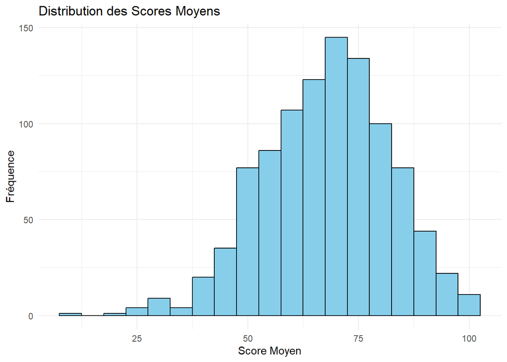

```r
#Visualisation
library(dplyr)
library(ggplot2)

# Histogramme des scores moyens
ggplot(students, aes(x = average_score)) +
  geom_histogram(binwidth = 5, fill = "skyblue", color = "black") +
  labs(title = "Distribution des Scores Moyens", x = "Score Moyen", y = "Fréquence") +
  theme_minimal()
```

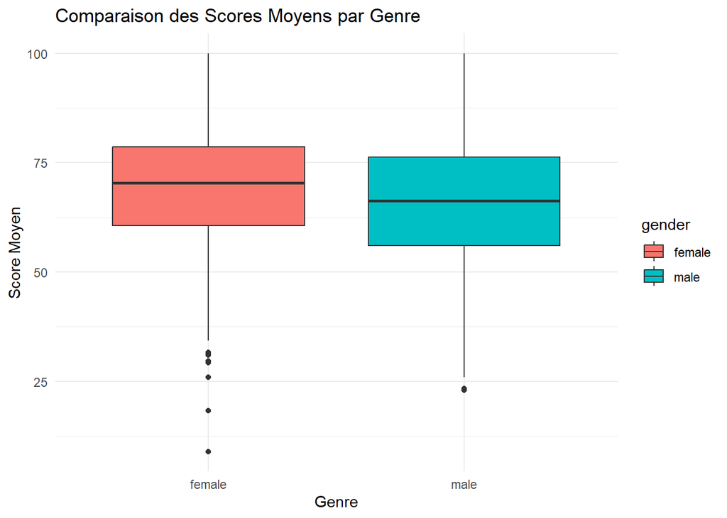

```r
# Boxplot par genre
ggplot(students, aes(x = gender, y = average_score, fill = gender)) +
  geom_boxplot() +
  labs(title = "Comparaison des Scores Moyens par Genre",
       x = "Genre", y = "Score Moyen") +
  theme_minimal()
```

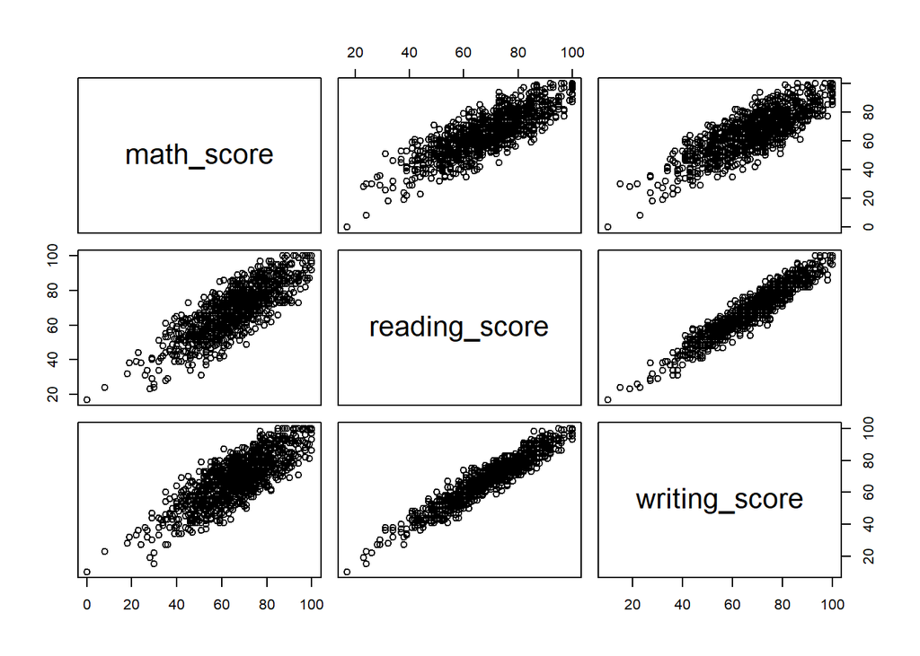

```r
# Relation entre les différents scores
pairs(students %>% select(math_score, reading_score, writing_score))
```

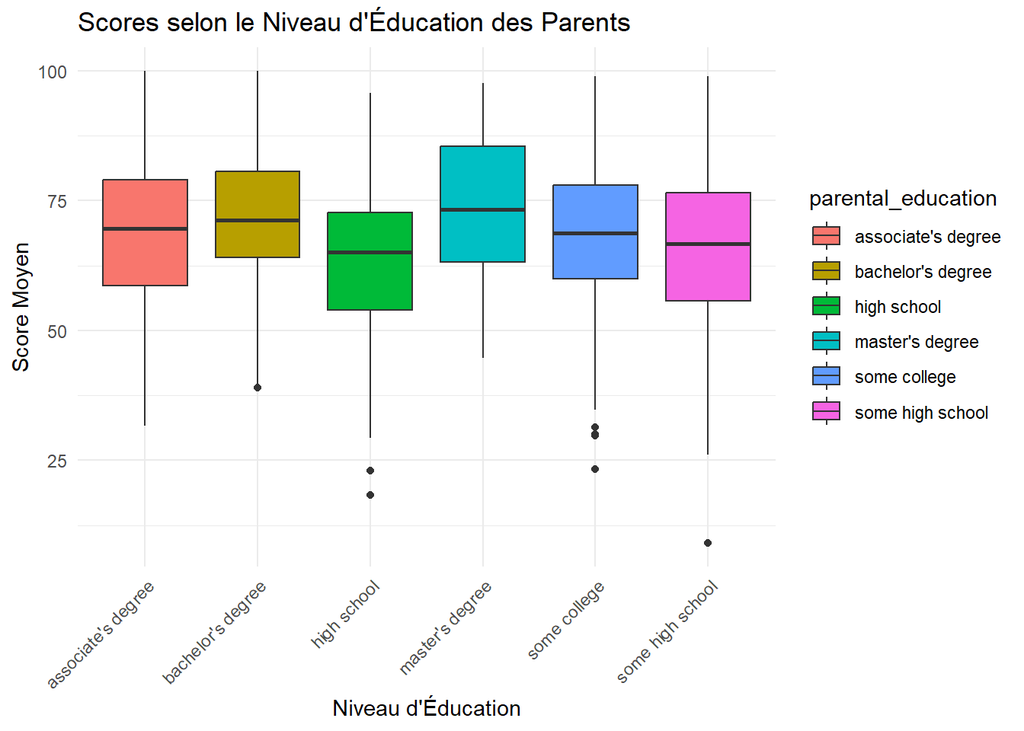

```r
# l'impact du niveau d'éducation des parents
# Visualisation par catégorie

ggplot(students, aes(x = parental_education, y = average_score, fill = parental_education)) +
  geom_boxplot() +
  labs(title = "Scores selon le Niveau d'Éducation des Parents",
       x = "Niveau d'Éducation", y = "Score Moyen") +
  theme_minimal() +
  theme(axis.text.x = element_text(angle = 45, hjust = 1))
```

Visualisation des Données et interpretation

Distribution des Scores Moyens

Comparaison des Scores Moyens par Genre

Corrélations entre les Scores

La matrice de scatter plots révèle des corrélations positives fortes entre les scores en mathématiques, lecture et écriture. - Les élèves qui réussissent dans une matière ont généralement de bons résultats dans les autres. - Cela indique une cohérence des performances académiques entre les disciplines.

Scores selon le Niveau d’Éducation des Parents

3. Statistiques Descriptives

```r
#Analyse statistique

# STATISTIQUES DESCRIPTIVES GLOBALES

# Résumé des scores
score_summary <- students %>%
  summarise(
    Observations = n(),
    `Moyenne Math` = round(mean(math_score), 1),
    `Moyenne Lecture` = round(mean(reading_score), 1),
    `Moyenne Écriture` = round(mean(writing_score), 1),
    `Moyenne Totale` = round(mean(total_score), 1),
    `Écart-type Total` = round(sd(total_score), 1),
    `Minimum Total` = min(total_score),
    `Maximum Total` = max(total_score)
  )

print(score_summary)
```

```
## # A tibble: 1 × 8
##   Observations `Moyenne Math` `Moyenne Lecture` `Moyenne Écriture`
##          <int>          <dbl>             <dbl>              <dbl>
## 1         1000           66.1              69.2               68.1
## # ℹ 4 more variables: `Moyenne Totale` <dbl>, `Écart-type Total` <dbl>,
## #   `Minimum Total` <dbl>, `Maximum Total` <dbl>
```

```r
score_summary %>%
  select(`Moyenne Totale`, `Écart-type Total`, `Minimum Total`, `Maximum Total`)
```

```
## # A tibble: 1 × 4
##   `Moyenne Totale` `Écart-type Total` `Minimum Total` `Maximum Total`
##              <dbl>              <dbl>           <dbl>           <dbl>
## 1             203.               42.8              27             300
```

Analyse Statistique des Scores

Le tableau statistique présente les principales mesures descriptives des performances des élèves sur les trois matières évaluées : mathématiques, lecture et écriture. Les moyennes par matière sont les suivantes :

. Mathématiques : 66,1 . Lecture : 69,2 . Écriture : 68,1

La moyenne totale (somme des trois scores) est de 203,3 points. L’écart-type total est de 42,8, ce qui indique une variabilité modérée des scores globaux entre les élèves. Le score total minimum observé est de 27, tandis que le maximum atteint 300, soit le score parfait.

les résultats montre que la majorité des élèves obtiennent des scores moyens autour de 65 à 70 par matière, avec une dispersion notable. La présence d’un score total aussi bas que 27 montre qu’il y’a des eleve en difficulte , tandis que le score maximal indique que certains élèves ont excellé dans toutes les matières.

. Tests d’Hypothèses

```r
#test d'hypothese

#diff entre genre
test_genre <- t.test(average_score ~ gender, data = students)
print(test_genre)
```

```
##
##  Welch Two Sample t-test
##
## data:  average_score by gender
## t = 4.1789, df = 997.85, p-value = 3.186e-05
## alternative hypothesis: true difference in means between group female and group male is not equal to 0
## 95 percent confidence interval:
##  1.979515 5.484516
## sample estimates:
## mean in group female   mean in group male
##             69.56950             65.83748
```

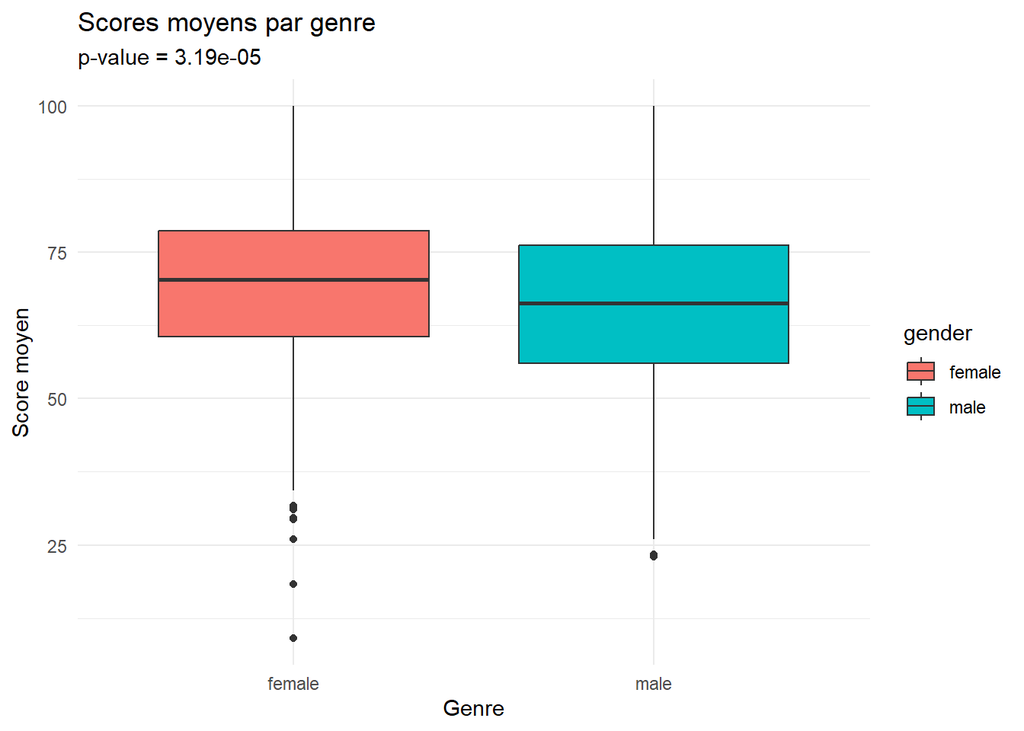

```r
# Visualisation correspondante
ggplot(students, aes(x = gender, y = average_score, fill = gender)) +
  geom_boxplot() +
  labs(title = "Scores moyens par genre",
       subtitle = paste("p-value =", format.pval(test_genre$p.value, digits = 3)),
       x = "Genre", y = "Score moyen") +
  theme_minimal()
```

```r
#impact de la prepa au test

t_test_prep <- t.test(average_score ~ test_prep, data = students)
print(t_test_prep)
```

```
##
##  Welch Two Sample t-test
##
## data:  average_score by test_prep
## t = 8.5945, df = 791.84, p-value < 2.2e-16
## alternative hypothesis: true difference in means between group completed and group none is not equal to 0
## 95 percent confidence interval:
##  5.887734 9.373305
## sample estimates:
## mean in group completed      mean in group none
##                72.66946                65.03894
```

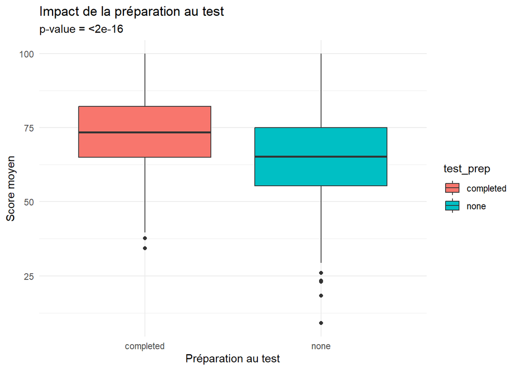

```r
# Visualisation correspondante
ggplot(students, aes(x = test_prep, y = average_score, fill = test_prep)) +
  geom_boxplot() +
  labs(title = "Impact de la préparation au test",
       subtitle = paste("p-value =", format.pval(t_test_prep$p.value, digits = 3)),
       x = "Préparation au test", y = "Score moyen") +
  theme_minimal()
```

```r
# Impact de l'éducation parentale
anova_parent <- aov(average_score ~ parental_education, data = students)
summary(anova_parent)
```

```
##                     Df Sum Sq Mean Sq F value   Pr(>F)
## parental_education   5  10420  2084.1   10.75 4.38e-10 ***
## Residuals          994 192648   193.8
## ---
## Signif. codes:  0 '***' 0.001 '**' 0.01 '*' 0.05 '.' 0.1 ' ' 1
```

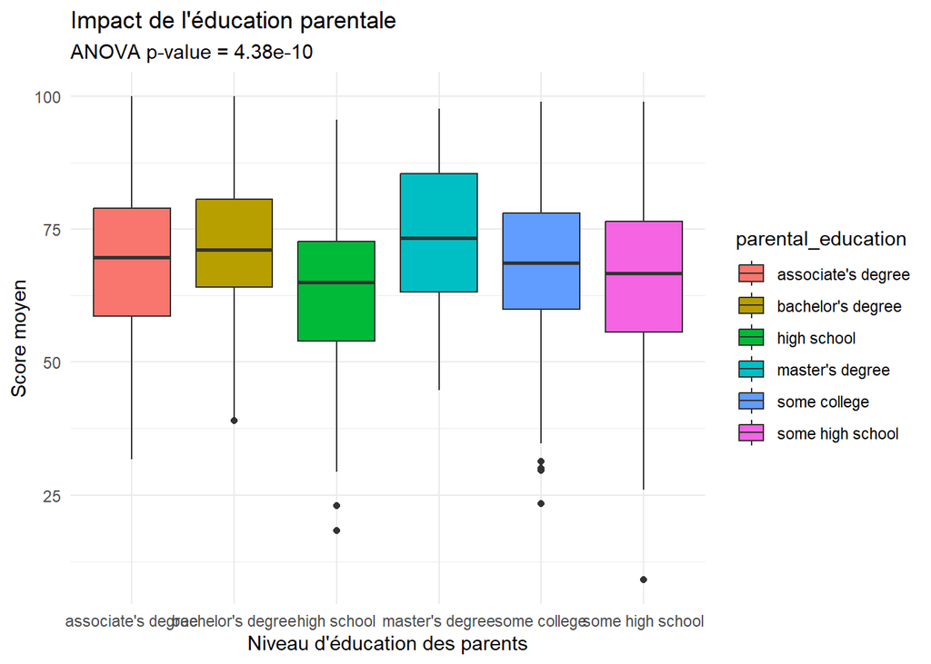

```r
# Visualisation correspondante
ggplot(students, aes(x = parental_education, y = average_score, fill = parental_education)) +
  geom_boxplot() +
  labs(title = "Impact de l'éducation parentale",
       subtitle = paste("ANOVA p-value =",
                        format.pval(summary(anova_parent)[[1]][["Pr(>F)"]][1], digits = 3)),
       x = "Niveau d'éducation des parents", y = "Score moyen") +
  theme_minimal()
```

```r
# Calcul des moyennes et intervalles de confiance par niveau d'éducation parentale

library(dplyr)

parent_means <- students %>%
  group_by(parental_education) %>%
  summarise(
    Moyenne = mean(average_score),
    IC_inf = mean(average_score) - qt(0.975, df = n()-1) * sd(average_score)/sqrt(n()),
    IC_sup = mean(average_score) + qt(0.975, df = n()-1) * sd(average_score)/sqrt(n()),
    .groups = "drop"
  )

print(parent_means)
```

```
## # A tibble: 6 × 4
##   parental_education Moyenne IC_inf IC_sup
##   <fct>                <dbl>  <dbl>  <dbl>
## 1 associate's degree    69.6   67.8   71.4
## 2 bachelor's degree     71.9   69.4   74.5
## 3 high school           63.1   61.2   65.0
## 4 master's degree       73.6   70.1   77.1
## 5 some college          68.5   66.7   70.3
## 6 some high school      65.1   62.9   67.3
```

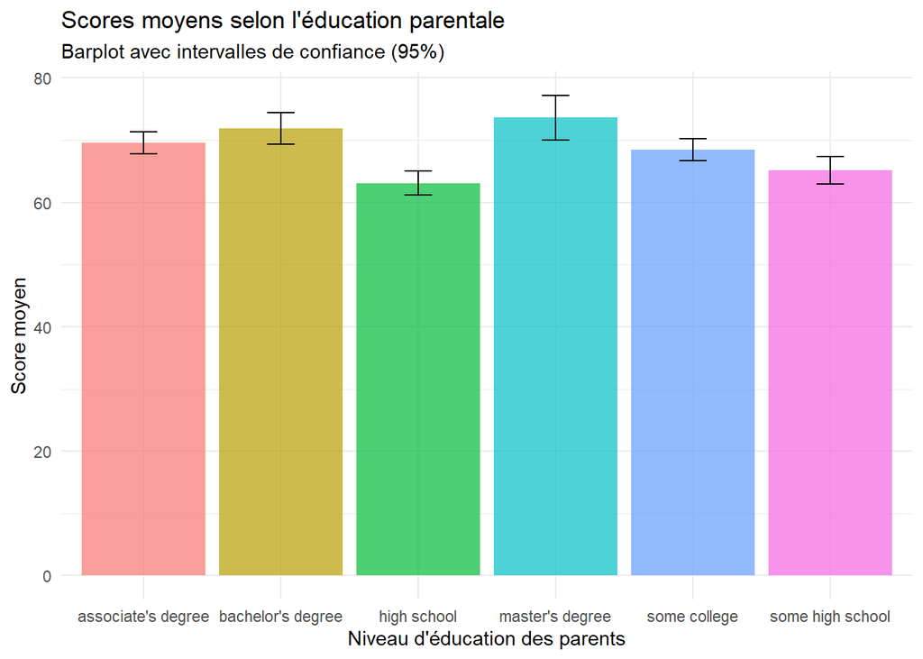

```r
# Barplot avec intervalles de confiance
ggplot(parent_means, aes(x = parental_education, y = Moyenne, fill = parental_education)) +
  geom_col(alpha = 0.7) +
  geom_errorbar(aes(ymin = IC_inf, ymax = IC_sup), width = 0.2) +
  labs(title = "Scores moyens selon l'éducation parentale",
       subtitle = "Barplot avec intervalles de confiance (95%)",
       x = "Niveau d'éducation des parents", y = "Score moyen") +
  theme_minimal() +
  theme(legend.position = "none")
```

Analyse des Hypothèses Statistiques

Différence de scores moyens selon le genre

Le test montre une différence significative entre les scores moyens des filles et des garçons (t = 4.18, p < 0.001). Les filles obtiennent en moyenne 69,6 points, contre 65,8 points pour les garçons.

L’intervalle de confiance à 95 % [1,98 ; 5,48] confirme que cette différence est statistiquement robuste.

Interprétation : Les filles tendent à obtenir des scores moyens plus élevés que les garçons.

Effet de la préparation au test

Le test montre une différence très significative entre les élèves ayant suivi un cours de préparation et ceux qui ne l’ont pas fait (t = 8.59, p < 0.001). - Moyenne avec préparation : 72,7 points. - Moyenne sans préparation : 65,0 points. - Intervalle de confiance [5,89 ; 9,37].

Interprétation : La préparation au test a un effet positif marqué sur les performances scolaires.

Influence du niveau d’éducation des parents

L’ANOVA indique que le niveau d’éducation parental a un effet significatif sur les scores (F = 10.75, p < 0.001).

Les moyennes varient selon le diplôme : Master’s degree : 73,6 Bachelor’s degree : 71,9 Associate’s degree : 69,6 Some college : 68,5 Some high school : 65,1 High school : 63,1

. Corrélations

```r
 #Matrice de corrélation

 cor_matrix <- cor(students %>%
                     select(math_score, reading_score, writing_score))
 cor_matrix
```

```
##               math_score reading_score writing_score
## math_score     1.0000000     0.8175797     0.8026420
## reading_score  0.8175797     1.0000000     0.9545981
## writing_score  0.8026420     0.9545981     1.0000000
```

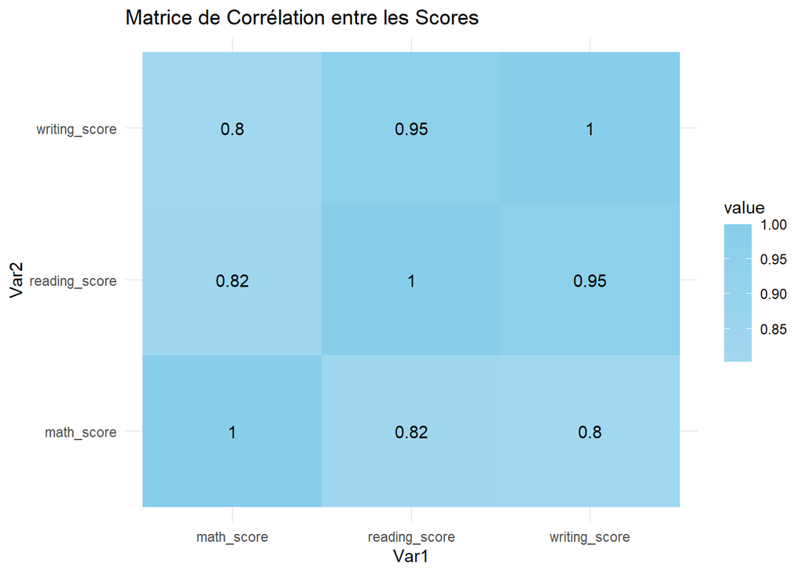

```r
 # Visualisation de la corrélation

 library(tidyr)
 library(tibble)


 melted_cor <- cor_matrix %>%
   as.data.frame() %>%
   rownames_to_column("Var1") %>%
   pivot_longer(-Var1, names_to = "Var2", values_to = "value")

 ggplot(melted_cor, aes(Var1, Var2, fill = value)) +
   geom_tile() +
   scale_fill_gradient2(low = "blue", high = "skyblue", mid = "white", midpoint = 0) +
   geom_text(aes(label = round(value, 2))) +
   labs(title = "Matrice de Corrélation entre les Scores") +
   theme_minimal()
```

Corrélation entre les Scores

Ces coefficients indiquent des corrélations fortes entre toutes les paires de variables. En particulier, la relation entre lecture et écriture est très étroite (r = 0.95), ce qui suggère que les compétences verbales sont fortement liées.

Interprétation :

Les élèves qui réussissent dans une matière ont tendance à bien performer dans les autres. Cela reflète une cohérence globale des compétences académiques, et justifie l’utilisation d’un score moyen comme indicateur synthétique de performance.

4. Modélisation Linéaire

#Modele 1

```r
#Modélisation simple

 # Régression linéaire

 library(broom)

 #Modèle 1 : Lecture et écriture

 model1 <- lm(math_score ~ reading_score + writing_score, data = students)
 tidy(model1)
```

```
## # A tibble: 3 × 5
##   term          estimate std.error statistic  p.value
##   <chr>            <dbl>     <dbl>     <dbl>    <dbl>
## 1 (Intercept)      7.52     1.33        5.66 1.93e- 8
## 2 reading_score    0.601    0.0630      9.54 1.08e-20
## 3 writing_score    0.249    0.0606      4.12 4.14e- 5
```

```r
 glance(model1)
```

```
## # A tibble: 1 × 12
##   r.squared adj.r.squared sigma statistic   p.value    df logLik   AIC   BIC
##       <dbl>         <dbl> <dbl>     <dbl>     <dbl> <dbl>  <dbl> <dbl> <dbl>
## 1     0.674         0.673  8.67     1031. 2.25e-243     2 -3577. 7162. 7181.
## # ℹ 3 more variables: deviance <dbl>, df.residual <int>, nobs <int>
```

Résultats du modèle

- Intercept : 7,52

Lecture (reading_score) : 0,60

Écriture (writing_score) : 0,25

Significativité des variables

Interprétation

# Modele 2

```r
library(broom)

 #Modèle 2 : ajout du genre et la preparaion au test

 model2 <- lm(math_score ~ reading_score + writing_score + gender + test_prep, data = students)
 tidy(model2)
```

```
## # A tibble: 5 × 5
##   term          estimate std.error statistic   p.value
##   <chr>            <dbl>     <dbl>     <dbl>     <dbl>
## 1 (Intercept)    -10.9      1.13       -9.64 4.28e- 21
## 2 reading_score    0.298    0.0442      6.75 2.51e- 11
## 3 writing_score    0.698    0.0443     15.8  4.19e- 50
## 4 gendermale      13.6      0.397      34.3  7.81e-171
## 5 test_prepnone    3.58     0.420       8.54 5.16e- 17
```

```r
 glance(model2)
```

```
## # A tibble: 1 × 12
##   r.squared adj.r.squared sigma statistic p.value    df logLik   AIC   BIC
##       <dbl>         <dbl> <dbl>     <dbl>   <dbl> <dbl>  <dbl> <dbl> <dbl>
## 1     0.851         0.851  5.85     1426.       0     4 -3184. 6379. 6409.
## # ℹ 3 more variables: deviance <dbl>, df.residual <int>, nobs <int>
```

Résultats principaux

Qualité du modèle

Interprétation

Ce modèle met en évidence l’importance combinée des compétences académiques (lecture, écriture) et des facteurs contextuels (genre, préparation) dans la prédiction des performances scolaires, expliquant une très grande part de la variabilité observée.

#Modele 3

```r
library(broom)
#Modèle 3 : Ajout de l’éducation parentale

 model3 <- lm(math_score ~ reading_score + writing_score + gender + test_prep + parental_education, data = students)
 tidy(model3)
```

```
## # A tibble: 10 × 5
##    term                                estimate std.error statistic   p.value
##    <chr>                                  <dbl>     <dbl>     <dbl>     <dbl>
##  1 (Intercept)                          -11.8      1.22      -9.63  4.80e- 21
##  2 reading_score                          0.273    0.0446     6.13  1.23e-  9
##  3 writing_score                          0.735    0.0453    16.2   1.28e- 52
##  4 gendermale                            13.7      0.396     34.7   5.63e-173
##  5 test_prepnone                          3.74     0.421      8.89  2.87e- 18
##  6 parental_educationbachelor's degree   -1.39     0.666     -2.08  3.74e-  2
##  7 parental_educationhigh school          0.529    0.578      0.914 3.61e-  1
##  8 parental_educationmaster's degree     -2.51     0.857     -2.93  3.42e-  3
##  9 parental_educationsome college         0.310    0.550      0.564 5.73e-  1
## 10 parental_educationsome high school     0.420    0.591      0.710 4.78e-  1
```

```r
 glance(model3)
```

```
## # A tibble: 1 × 12
##   r.squared adj.r.squared sigma statistic p.value    df logLik   AIC   BIC
##       <dbl>         <dbl> <dbl>     <dbl>   <dbl> <dbl>  <dbl> <dbl> <dbl>
## 1     0.854         0.853  5.81      645.       0     9 -3174. 6370. 6424.
## # ℹ 3 more variables: deviance <dbl>, df.residual <int>, nobs <int>
```

Interpretation

Le modèle 3 est robuste et met en évidence que les performances scolaires dépendent surtout des compétences académiques, du genre et de la préparation au test, tandis que l’effet du niveau d’éducation des parents est plus limité et parfois inattendu.

.Comparaison des modeles

```r
# Comparaison des modèles

 library(purrr)

 model_comparison <- list(model1 = model1, model2 = model2, model3 = model3) %>%
   map_df(glance, .id = "model")

 model_comparison %>%
   select(model, r.squared, adj.r.squared, AIC, BIC, sigma, df.residual)
```

```
## # A tibble: 3 × 7
##   model  r.squared adj.r.squared   AIC   BIC sigma df.residual
##   <chr>      <dbl>         <dbl> <dbl> <dbl> <dbl>       <int>
## 1 model1     0.674         0.673 7162. 7181.  8.67         997
## 2 model2     0.851         0.851 6379. 6409.  5.85         995
## 3 model3     0.854         0.853 6370. 6424.  5.81         990
```

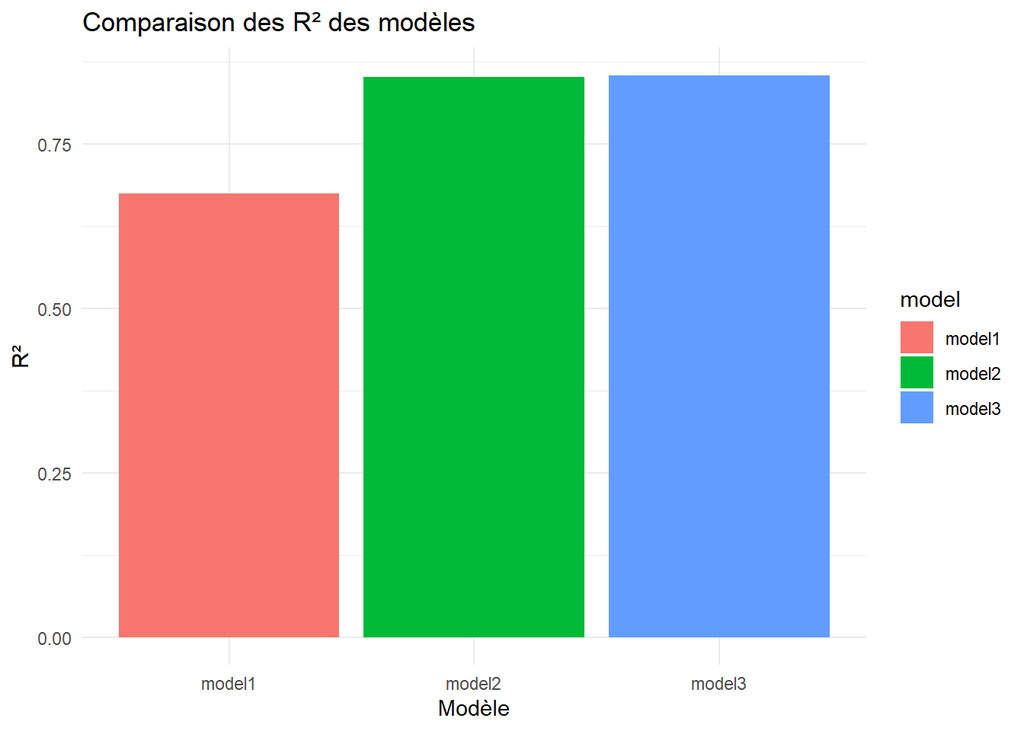

```r
 model_comparison %>%
   ggplot(aes(x = model, y = r.squared, fill = model)) +
   geom_col() +
   labs(title = "Comparaison des R² des modèles",
        x = "Modèle", y = "R²") +
   theme_minimal()
```

Comparaison des Trois Modèles

Le graphique comparatif des R² montre clairement l’évolution de la qualité prédictive des modèles :

Modèle 1 (lecture + écriture) : R² ≈ 0,67 Ce modèle de base explique une part correcte de la variance, mais reste limité aux compétences académiques.

Modèle 2 (+ genre + préparation au test) : R² ≈ 0,85 L’ajout de variables contextuelles améliore fortement la performance du modèle. Le genre et la préparation au test ont un impact significatif sur les scores.

Modèle 3 (+ éducation des parents) : R² ≈ 0,85 L’ajout du niveau d’éducation des parents n’améliore pas significativement le pouvoir explicatif par rapport au modèle 2. Certains niveaux ont un effet faible ou non significatif

.Comparaison des residus

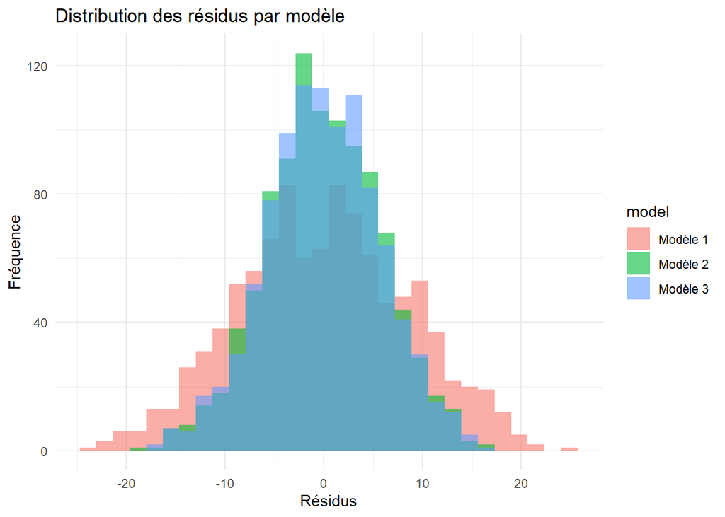

```r
#comparaison resudis des 3 modele

 bind_rows(
   augment(model1) %>% mutate(model = "Modèle 1"),
   augment(model2) %>% mutate(model = "Modèle 2"),
   augment(model3) %>% mutate(model = "Modèle 3")
 ) %>%
   ggplot(aes(x = .resid, fill = model)) +
   geom_histogram(alpha = 0.6, bins = 30, position = "identity") +
   labs(title = "Distribution des résidus par modèle",
        x = "Résidus", y = "Fréquence") +
   theme_minimal()
```

Analyse des Résidus par Modèle

Le graphique montre la distribution des résidus pour les trois modèles testés :

Les résidus des modèles 2 et 3 (en vert et bleu) sont plus concentrés autour de zéro, avec une dispersion plus faible, ce qui indique une meilleure précision des prédictions. Le modèle 1 (en rouge) présente une distribution plus étalée, ce qui reflète une erreur de prédiction plus élevée.

Interprétation Les modèles 2 et 3 sont plus performants, avec des résidus plus faibles et mieux répartis.

le modèle 1 est moins précis, ce qui confirme qu’ajouter des variables explicatives (genre, préparation, éducation parentale) améliore la qualité des prédictions.

.Verification des residus

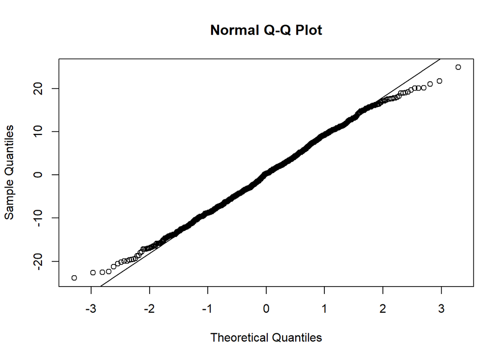

```r
 #verification des residus

 qqnorm(resid(model1)); qqline(resid(model1))
```

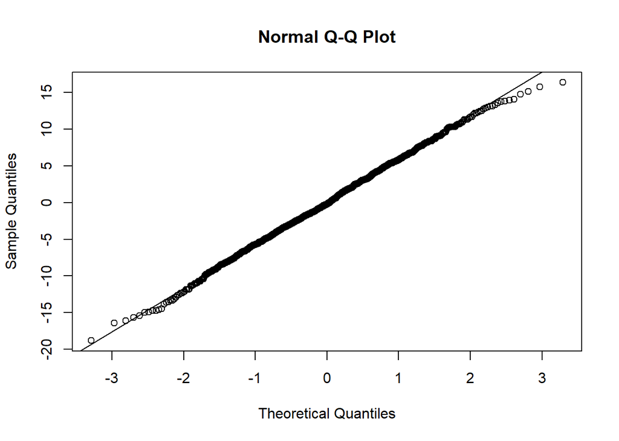

```r
 qqnorm(resid(model2)); qqline(resid(model2))
```

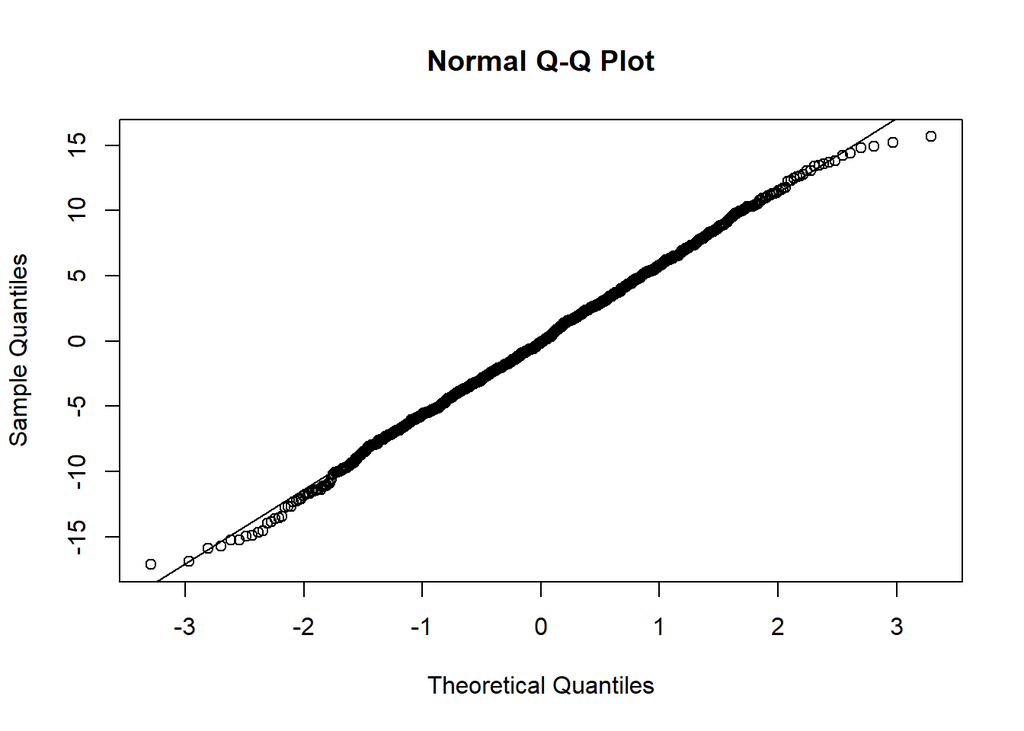

```r
 qqnorm(resid(model3)); qqline(resid(model3))
```